# Project explanation :

We used the NewsAPI, which allows us to execute requests on various articles. We chose to focus our study on the top 5 headlines about artificial intelligence using the API with the following URL: 'https://newsapi.org/v2/top-headlines?' 'q=Artificial Intelligence&' 'pageSize=5&' 'apiKey=2dc9629039304cbd8d0a69e75a3509ee'

## /get_data :

here is the output we have with /get_data :

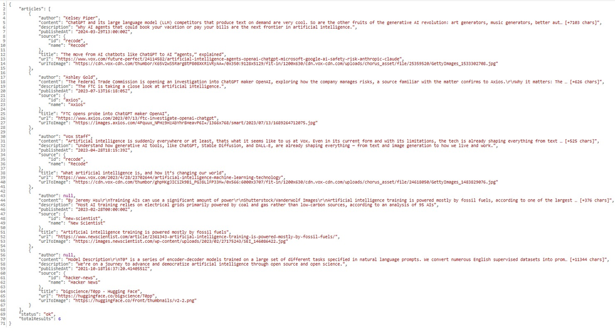

## /articles

The purpose of this endpoint is to display the main information of the 5 articles we have selected. The information we display includes the article number, title, description, source name, author, publication date, and URL. However, we do not display the detailed content of the selected article. To do this, we use requests.get() from our URL and select the information we are interested in.

here is the output we have with /articles :

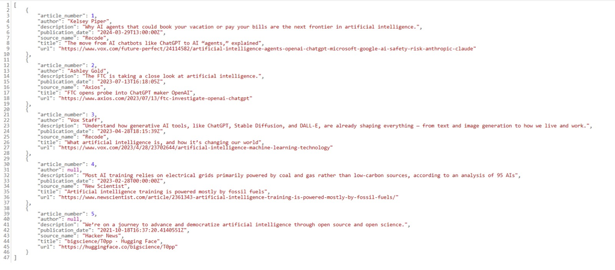

## /article/int:number

this endpoint is meant to be used on only 1 article and returns the entire content of the article and it's URL when the scrapping was sucessful. Otherwise, the content is given by the API and is troncated displaying the number of chars left.

here is an exemple for /article/1

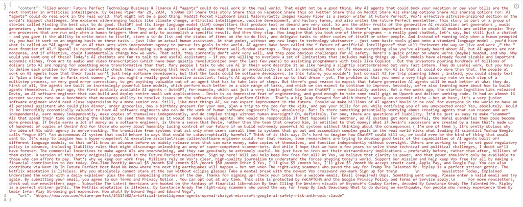

## /ml/int:number

This endpoint executes a machine learning script to get the sentiment analysis of the article corresponding to the article number provided. In order to get the sentiment analysis, we used the NLTK library which gives us the scores about content of one article. Then, we implemented a function that returns an analysis corresponding to a specific score.

here is an exemple /ml/1

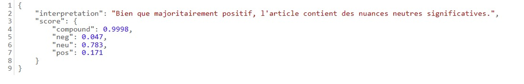